# Lab 4: Topic Analysis

Mateo Robbins

## Background: Latent Dirichlet Allocation

Latent Dirichlet Allocation (LDA) is a generative probabilistic model that treats each document as a mixture of topics, and each topic as a mixture of words. Understanding the key variables helps interpret model outputs:

| Symbol | Name | Role |
| --- | --- | --- |
| **α** (alpha) | Hyperparameter | Dirichlet prior on document-topic distributions. Small α → each document focuses on few topics. Set by researcher. |
| **β** (beta) | Hyperparameter | Dirichlet prior on topic-word distributions. Small β → each topic uses a focused vocabulary. Set by researcher. |
| **θ** (theta) | Document-topic distribution | Probability distribution over topics for each document. *P(topic \| document)*. Latent — must be inferred. |
| **φ** (phi) | Topic-word distribution | Probability distribution over vocabulary for each topic. *P(word \| topic)*. Called `beta` in tidytext. Latent — must be inferred. |
| **z** | Topic assignment | The hidden topic label allocated to each individual word token. The bridge between θ and φ. Latent — must be inferred. |
| **w** | Observed word | The only variable you actually see. Everything else is inferred from patterns in w. |

### The Generative Assumptions

LDA imagines that documents were written as follows:

1. For each topic *t*, draw a word distribution **φ_t** ~ Dirichlet(β)
2. For each document *m*, draw a topic distribution **θ_m** ~ Dirichlet(α)
3. For each word position in that document:
   - Draw a topic assignment **z** ~ Multinomial(θ_m)
   - Draw the word **w** ~ Multinomial(φ_z)

Inference runs this process in reverse: given the observed words **w**, recover the most probable **z**, **θ**, and **φ**.

### The Dirichlet Distribution

The Dirichlet distribution is a *distribution over distributions* — it produces probability vectors that sum to 1, making it ideal for representing topic mixtures and word mixtures. The concentration parameter (α or β) controls sparsity:

- **Small value (< 1)**: samples are sparse — most probability sits on one or two categories. Realistic for most text corpora.
- **Large value (> 1)**: samples are spread evenly across all categories.
- **Value = 1**: uniform — all mixtures equally likely.

## Lab Setup

```r
library(quanteda)
library(tm)
library(topicmodels)
library(topicdoc)
library(tidyverse)
library(tidytext)
library(reshape2)
library(tictoc)
library(LDAvis)
library(tsne)
library(servr)
```

## Load the Data

```r
tbl <- read_csv("https://raw.githubusercontent.com/MaRo406/EDS-231-text-sentiment/refs/heads/main/data/nexis-dat.csv")
```

## Build the Corpus

We use `corpus()` from {quanteda} to build the corpus from our data frame.

```r
corpus <- corpus(x = tbl,
                 textg_field = "text")
```

## Tokenize and Clean

`tokens()` handles punctuation and number removal. We also build a custom stopword list that removes common journalistic filler words that carry no thematic signal. We can return to this section to add additional words once we see the results.

```r
add_stops <- c(quanteda::stopwords("en",
                                   source="smart"), # What leixcons
               # Other high freuqency words/tokens
               "said", "says", "told", "according")

# Tokenize
toks <- tokens(corpus, remove_punct = TRUE) %>%
  # Normalize
  tokens_tolower()

toks1 <- tokens_select(toks, # Select this
                       pattern = add_stops,
                       selection = "remove") # remove when detect pattern in toks
```

## Build the Document-Feature Matrix

Topic modeling requires a document-feature matrix (DFM). We trim rare terms (appearing in fewer than 2 documents) and remove empty rows — LDA cannot process documents with no terms.

```r
dfm1 <- dfm(toks1) # dfm your toks
dfm2 <- dfm_trim(dfm1, min_docfreq = 2)

# Remove empty rows — LDA will error on these
sel_idx <- slam::row_sums(dfm2) > 0 # select no empty rows
dfm <- dfm2[sel_idx,] # subset
```

dfm - number of documents and number of unique tokens per each document

## Step 1: Initial Model (Theory-Driven k)

Great, now we are almost ready to run a model. We just have to come up with an initial value for k, the number of latent topics present in the data. How do we do this? Let’s say I think there may be political, economic and environmental articles. So I will tell the model to look for 3 topics by setting the k parameter = 3.

```r
# Number of laten topis in data - # of broad themes
# Hyperparameter
k <- 3

topicModel_k3 <- LDA(dfm, # matrix
                      k,
                      method = "Gibbs", # Gibbs is default (always do this)
                      control = list(iter = 100, # Number of iterations
                                     verbose = 25, # Tell us after every 25 iterations
                                     seed = 321
                                     ))
```

```
## K = 3; V = 14497; M = 558
## Sampling 100 iterations!
## Iteration 25 ...
## Iteration 50 ...
## Iteration 75 ...
## Iteration 100 ...
## Gibbs sampling completed!
```

### Inspect the Posterior Distributions

`posterior()` extracts the two key output matrices:

- **theta (θ)**: document × topic matrix — *P(topic | document)*
- **beta/phi (φ)**: topic × term matrix — *P(term | topic)*

```r
result <- posterior(topicModel_k3)

beta  <- result$terms
theta <- result$topcis

cat("phi dimensions  (topics × vocab):", dim(beta), "\n")
```

```
## phi dimensions  (topics × vocab): 3 14497
```

```r
cat("theta dimensions (docs × topics):", dim(theta), "\n")
```

```
## theta dimensions (docs × topics):
```

```r
# Top 10 terms per topic
terms(topicModel_k3, 10)
```

```
##       Topic 1       Topic 2     Topic 3
##  [1,] "energy"      "people"    "data"
##  [2,] "power"       "trump"     "ai"
##  [3,] "data"        "time"      "center"
##  [4,] "centers"     "mr"        "1"
##  [5,] "state"       "years"     "company"
##  [6,] "electricity" "lot"       "market"
##  [7,] "center"      "president" "2"
##  [8,] "water"       "world"     "technology"
##  [9,] "gas"         "things"    "companies"
## [10,] "$"           "work"      "infrastructure"
```

These are the 3 topics and the words that belong to each topic.

Most probable word for each topic

Probability for each word occurrence

## Step 2: Selecting k with Coherence Scores

An alternative to theory-driven k selection is to fit models across a range of k values and evaluate them statistically. We use `topicdoc::topic_coherence()`, which measures whether the top words of each topic co-occur frequently in the corpus — a proxy for human interpretability. We can do this efficiently by running a sequence of models, each with a different value of k.

**Higher coherence = more semantically meaningful topics.**

```r
# Fit models for a range of k values
k_values <- seq(2, 15, by = 1) # Range of Ks

tic() # Set a timer to know how long a model took
# run model on each K simulation
coherence_results <- map_dfr(k_values, function(k){ # Loop thru Ks
  # Fun the model
  m <- LDA(dfm, k = k,
      method = "Gibbs",
      control = list(iter = 300, # Choose lower one for time
                     seed = 231,
                     verbos = 0))
  # Calculate coherence
  coh <- mean(topic_coherence(m, dfm))
  tibble(k=k, coherence = coh)
  })
toc() # Set a timer to know how long a model took
```

```
## 64.316 sec elapsed
```

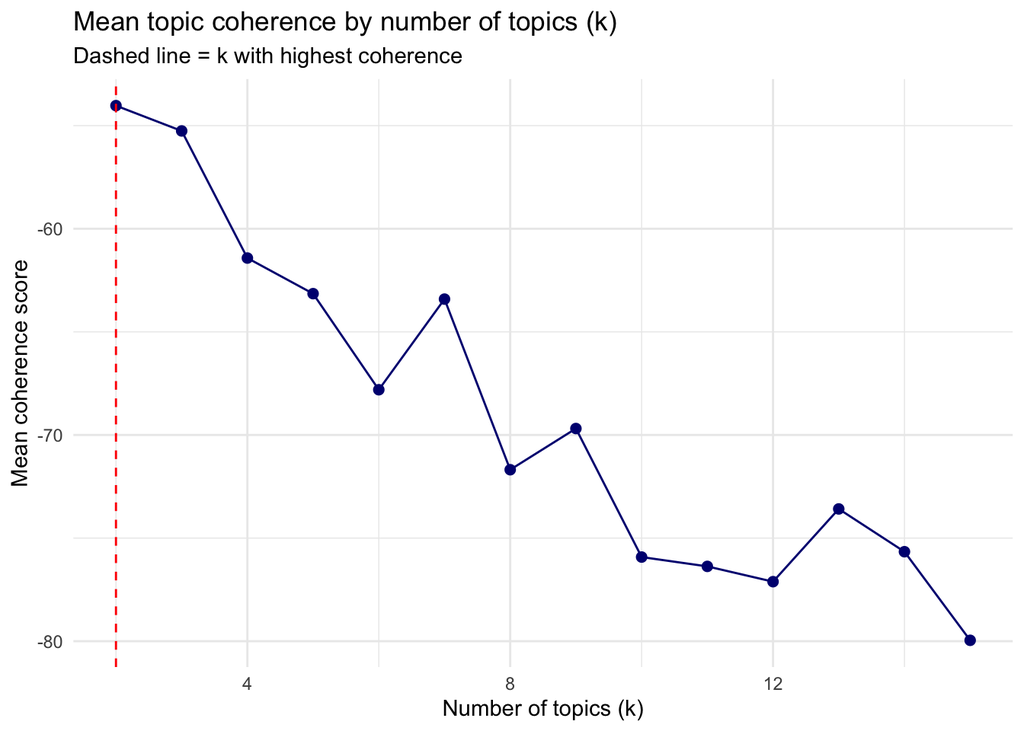

```r
# Plot coherence vs k — look for the peak or elbow
ggplot(coherence_results, aes(x = k, y = coherence)) +
  geom_line(color = "navy") +
  geom_point(color = "navy", size = 2) +
  geom_vline(xintercept = coherence_results$k[which.max(coherence_results$coherence)], # Best coh score
             linetype = "dashed", color = "red") +
  labs(title = "Mean topic coherence by number of topics (k)",
       subtitle = "Dashed line = k with highest coherence",
       x = "Number of topics (k)",
       y = "Mean coherence score") +
  theme_minimal()
```

> **Interpreting the plot:** Look for the peak coherence value, or an “elbow” where adding more topics stops improving coherence meaningfully. Also inspect the top terms at two or three candidate k values — statistical criteria and human interpretability do not always agree. Your final choice of k should be justified on both grounds.

Based on coh score, 2 is best for our data which is common but might be bias (not ‘end all be all’) - maybe have 2 years that are causing the 2 binning.

Maybe choose an overall maximum (a peak) - an elbow.

The best score is least negative.

coh = log of the probability of the word appearing

## Step 3: Fit the Selected Model

```r
k <- 6  # update this based on your coherence plot

topicModel_k_select <- LDA(dfm, k,
                           method = "Gibbs",
                           control = list(iter = 1000, # Increasing the quality of model result
                                          verbose = 25,
                                          seed = 321))
```

```
## K = 6; V = 14497; M = 558
## Sampling 1000 iterations!
## Iteration 25 ...
## Iteration 50 ...
## Iteration 75 ...
## Iteration 100 ...
## Iteration 125 ...
## Iteration 150 ...
## Iteration 175 ...
## Iteration 200 ...
## Iteration 225 ...
## Iteration 250 ...
## Iteration 275 ...
## Iteration 300 ...
## Iteration 325 ...
## Iteration 350 ...
## Iteration 375 ...
## Iteration 400 ...
## Iteration 425 ...
## Iteration 450 ...
## Iteration 475 ...
## Iteration 500 ...
## Iteration 525 ...
## Iteration 550 ...
## Iteration 575 ...
## Iteration 600 ...
## Iteration 625 ...
## Iteration 650 ...
## Iteration 675 ...
## Iteration 700 ...
## Iteration 725 ...
## Iteration 750 ...
## Iteration 775 ...
## Iteration 800 ...
## Iteration 825 ...
## Iteration 850 ...
## Iteration 875 ...
## Iteration 900 ...
## Iteration 925 ...
## Iteration 950 ...
## Iteration 975 ...
## Iteration 1000 ...
## Gibbs sampling completed!
```

```r
tmResult <- posterior(topicModel_k_select)
terms(topicModel_k_select, 10)
```

```
##       Topic 1          Topic 2         Topic 3          Topic 4    Topic 5
##  [1,] "data"           "energy"        "trump"          "people"   "data"
##  [2,] "1"              "power"         "people"         "systems"  "centers"
##  [3,] "market"         "electricity"   "president"      "time"     "center"
##  [4,] "2"              "gas"           "american"       "amazon"   "state"
##  [5,] "center"         "solar"         "world"          "mr"       "$"
##  [6,] "cloud"          "climate"       "administration" "system"   "power"
##  [7,] "services"       "states"        "$"              "years"    "project"
##  [8,] "digital"        "nuclear"       "time"           "security" "water"
##  [9,] "infrastructure" "environmental" "douthat"        "change"   "bill"
## [10,] "centers"        "emissions"     "years"          "work"     "county"
##       Topic 6
##  [1,] "ai"
##  [2,] "university"
##  [3,] "students"
##  [4,] "news"
##  [5,] "city"
##  [6,] "program"
##  [7,] "technology"
##  [8,] "2025"
##  [9,] "companies"
## [10,] "open"
```

```r
theta <- tmResult$topics
beta  <- tmResult$terms
vocab <- colnames(beta)
```

## Step 4: Visualize Top Terms per Topic

The β (φ) matrix gives us *P(term | topic)*. Plotting the highest-probability terms for each topic is the primary tool for human interpretation of what each topic “means.”

Looking at 6 topics and the most probable words for each topic.

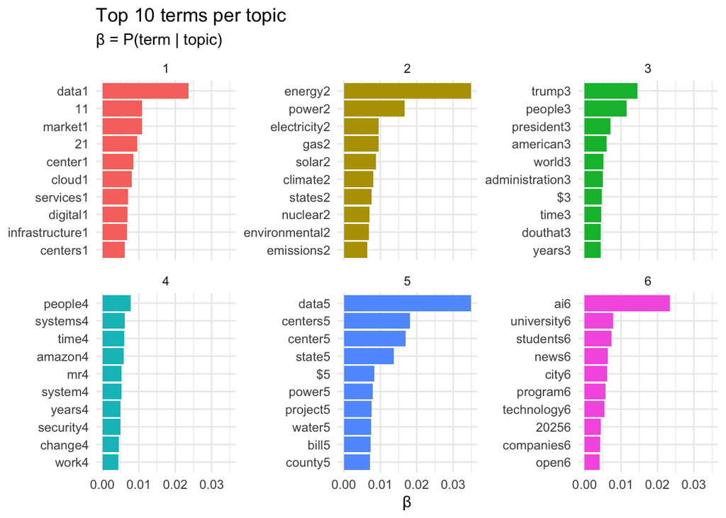

```r
topics <- tidy(topicModel_k_select, matrix = "beta")

top_terms <- topics |>
  group_by(topic) |>
  slice_max(beta, n = 10) |>
  ungroup() |>
  arrange(topic, -beta)

top_terms |>
  mutate(term = reorder_within(term, beta, topic, sep = "")) |>
  ggplot(aes(term, beta, fill = factor(topic))) +
  geom_col(show.legend = FALSE) +
  facet_wrap(~ topic, scales = "free_y") +
  scale_x_reordered() +
  coord_flip() +
  labs(title = "Top 10 terms per topic",
       subtitle = "β = P(term | topic)",
       x = NULL, y = "β") +
  theme_minimal()
```

Disproportional probability of word in each topic shows you something about the topic.

## Step 5: Name the Topics

Interpret each topic by examining its top terms and assigning a descriptive label. This is an inherently qualitative step — topic names should reflect genuine thematic content, not just the top terms mechanically concatenated.

Name the topics on the first couple words.

```r
topic_words <- terms(topicModel_k_select, 5)

# Option 1: auto-name from top 5 terms (ok for a first pass)
topic_names <- apply(topic_words, 2, paste, collapse = " ")

# Option 2: replace with your own interpretive labels after inspection
# topic_names <- c("Topic Name 1", "Topic Name 2",
#                  "Topic Name 3",  "Topic Name 4"...)

topic_names
```

```
##                                 Topic 1                                 Topic 2
##                "data 1 market 2 center"    "energy power electricity gas solar"
##                                 Topic 3                                 Topic 4
## "trump people president american world"         "people systems time amazon mr"
##                                 Topic 5                                 Topic 6
##           "data centers center state $"      "ai university students news city"
```

## Step 6: Document-Topic Distributions (θ)

The θ matrix shows how each document blends across topics. This reflects the allocation of word tokens **z** to topics within each document — a document with many words assigned to topic 2 will have high θ for topic 2.

**Distribution of topics on documents**

First 5 documents

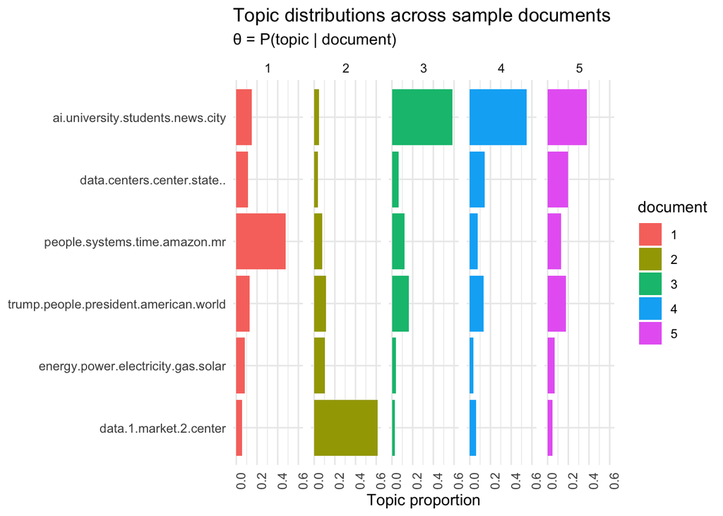

```r
example_ids <- c(1:5)
n <- length(example_ids)

example_props <- theta[example_ids, ]
colnames(example_props) <- topic_names

viz_df <- melt(cbind(data.frame(example_props),
                     document = factor(1:n)),
               variable.name = "topic",
               id.vars = "document")

ggplot(data = viz_df, aes(topic, value, fill = document)) +
  geom_bar(stat = "identity") +
  theme_minimal() +
  theme(axis.text.x = element_text(angle = 90, hjust = 1)) +
  coord_flip() +
  facet_wrap(~ document, ncol = n) +
  labs(title = "Topic distributions across sample documents",
       subtitle = "θ = P(topic | document)",
       x = NULL, y = "Topic proportion")
```

Could look overtime - which are the most prevalence topics in documents.

## Step 7: Interactive Visualization with LDAvis

LDAvis provides an interactive view of two complementary aspects of the model:

- **Intertopic distance map**: circles represent topics; size = proportion of corpus tokens assigned to that topic; distance = degree of topic overlap in vocabulary
- **Term relevance bar chart**: adjustable by the λ (lambda) parameter

### The λ (lambda) Relevance Parameter

λ controls the trade-off between term frequency and term exclusivity when ranking words within a topic:

$$\text{Relevance}(w, t) = \lambda \times
P(w|t) + (1 - \lambda) \times \frac{P(w|t)}{P(w)}$$

- **λ near 1**: ranks terms by raw frequency within the topic — highlights common words
- **λ near 0**: ranks terms by how *exclusive* they are to the topic relative to the whole corpus — highlights distinctive words, analogous to tf-idf
- **λ ≈ 0.6**: the empirically recommended default (Sievert & Shirley,
  2014. that balances both

```r
svd_tsne <- function(x) tsne(svd(x)$u)

json <- createJSON(
  phi           = tmResult$terms,
  theta         = tmResult$topics,
  doc.length    = rowSums(dfm),
  vocab         = colnames(dfm),
  term.frequency = colSums(dfm),
  mds.method    = svd_tsne,
  plot.opts     = list(xlab = "", ylab = "")
)

serVis(json)
```

[output not shown]

Circles overlapping ? –> redundent topcis

For each topic, term frequency

Most frequency in doc vs overall frequency across all documents

Lamba

## Assignment: Lab 4

For this assignment you will apply the full LDA pipeline to the Nexis Uni article data you downloaded in Week 2. Create a new .Rmd and complete the following:

**1. Build and clean your corpus**  
Create a corpus from your articles. Clean appropriately for your data — consider what stopwords, minimum document frequencies, and tokenization choices make sense given your specific corpus.

**2. Select k using multiple criteria**

Run three models (i.e. with 3 values of k) and select the overall best value for k (the number of topics) - include some justification for your selection: FindTopicsNumber() optimization metrics, theory, interpretability, LDAvis. Select the best single value of k. Criteria to consider:

- **Optimization Metrics** - Run models across a range of k values and produce a coherence plot using `topicdoc`.

- **Theory**: what themes do you expect given your article topic?

- **Interpretability**: read the top 10 terms at candidate k values — do they form coherent, distinct themes?

- **LDAvis**: do the topic circles separate well, or do they overlap heavily?

Select a single best k and write 2–3 sentences justifying your choice drawing on the three criteria.

**3. Fit your final model and visualize top terms**  
Plot the top 10 terms per topic.

**4. Visualize document-topic distributions**  
Plot θ for a sample of documents (5–10). Choose a sample size that produces a readable plot.

**5. Interpret your topics**  
Assign a descriptive name to each topic (not just the concatenated top terms). In a short paragraph per topic, describe:

- What theme or issue does this topic represent?

- Which words are most diagnostic of this interpretation?

- Are there any surprising or ambiguous words in the top terms?